# Projet Statistique : Analyse des données médicales

# 5 5. Analyse multivariée : régression linéaire multiple

Nous cherchons à expliquer le **score de symptômes** à partir des autres variables.

## 5.1 5.1 Modèle global

```r
modele_lm <- lm(
  Symptom_Score ~ Age + Sexe + Poids + Tension + Cholesterol + Groupe_Traitement + Suivi_Jours,
  data = data_clean
)

summary(modele_lm)
```

```
##
## Call:
## lm(formula = Symptom_Score ~ Age + Sexe + Poids + Tension + Cholesterol +
##     Groupe_Traitement + Suivi_Jours, data = data_clean)
##
## Residuals:
##     Min      1Q  Median      3Q     Max
## -5.4514 -2.0247  0.2219  2.0510  4.5342
##
## Coefficients:
##                     Estimate Std. Error t value Pr(>|t|)
## (Intercept)         9.207592   4.656931   1.977   0.0523 .
## Age                 0.022730   0.019950   1.139   0.2588
## SexeM              -0.319888   0.727147  -0.440   0.6615
## Poids               0.009679   0.022673   0.427   0.6709
## Tension            -0.017937   0.018220  -0.984   0.3286
## Cholesterol        -0.001958   0.011546  -0.170   0.8659
## Groupe_TraitementB -0.352014   0.668319  -0.527   0.6002
## Suivi_Jours        -0.081172   0.095565  -0.849   0.3988
## ---
## Signif. codes:  0 '***' 0.001 '**' 0.01 '*' 0.05 '.' 0.1 ' ' 1
##
## Residual standard error: 2.691 on 64 degrees of freedom
## Multiple R-squared:  0.06689,    Adjusted R-squared:  -0.03517
## F-statistic: 0.6554 on 7 and 64 DF,  p-value: 0.7085
```

Interprétation (générale) :  
- Le **R²** indique la proportion de la variabilité du score expliquée par le modèle.  
- Chaque coefficient représente l’effet **moyen** de la variable, **à variables constantes**.  
- Si le p-value d’un coefficient est **< 0,05**, l’effet est statistiquement significatif.

## 5.2 5.2 Coefficients sous forme de tableau propre

```r
tidy(modele_lm, conf.int = TRUE)
```

```
## # A tibble: 8 × 7
##   term               estimate std.error statistic p.value conf.low conf.high
##   <chr>                 <dbl>     <dbl>     <dbl>   <dbl>    <dbl>     <dbl>
## 1 (Intercept)         9.21       4.66       1.98   0.0523  -0.0957   18.5
## 2 Age                 0.0227     0.0200     1.14   0.259   -0.0171    0.0626
## 3 SexeM              -0.320      0.727     -0.440  0.661   -1.77      1.13
## 4 Poids               0.00968    0.0227     0.427  0.671   -0.0356    0.0550
## 5 Tension            -0.0179     0.0182    -0.984  0.329   -0.0543    0.0185
## 6 Cholesterol        -0.00196    0.0115    -0.170  0.866   -0.0250    0.0211
## 7 Groupe_TraitementB -0.352      0.668     -0.527  0.600   -1.69      0.983
## 8 Suivi_Jours        -0.0812     0.0956    -0.849  0.399   -0.272     0.110
```

## 5.3 5.3 Vérification des hypothèses du modèle

### 5.3.1 5.3.1 Résidus vs valeurs ajustées (homoscédasticité)

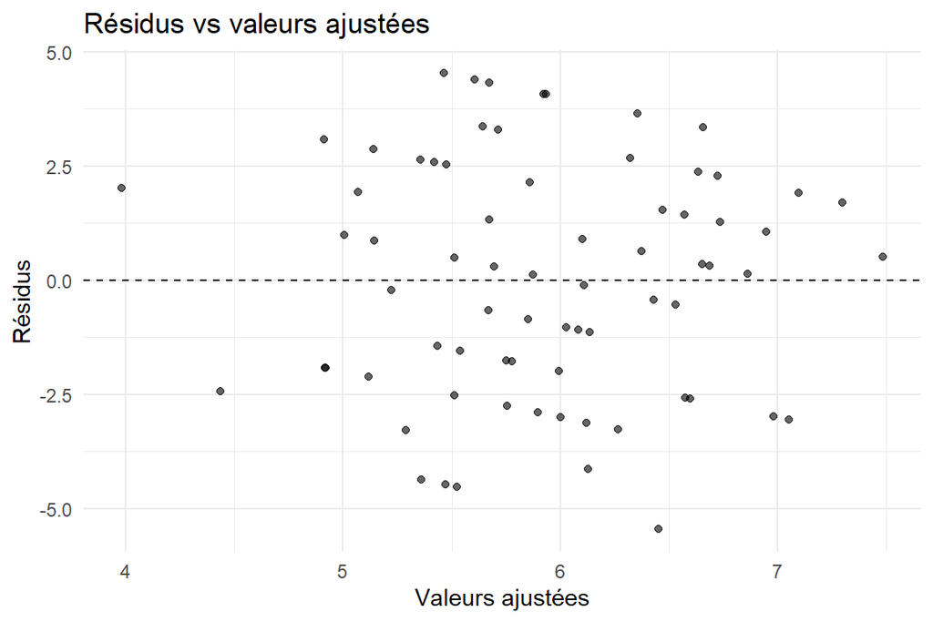

```r
ggplot(data.frame(
  fitted = fitted(modele_lm),
  resid = resid(modele_lm)
), aes(x = fitted, y = resid)) +
  geom_point(alpha = 0.6) +
  geom_hline(yintercept = 0, linetype = "dashed") +
  theme_minimal() +
  labs(title = "Résidus vs valeurs ajustées",
       x = "Valeurs ajustées",
       y = "Résidus")
```

Interprétation :  
> On recherche une **dispersion aléatoire** des résidus autour de 0.  
> Des motifs particuliers (courbe, entonnoir…) peuvent indiquer une violation de l’hypothèse d’homoscédasticité.